# Statistics_task_basic_3

## TASK 1

Write a function percentile(data, p) and test it with a list of 20 random values. Explanation: Sort the data, compute the exact percentile position, and return the interpolated value. It's formula is pos = p/100 * (n-1)

```python
def percentile(data, p):

    # lets sort data
    sorted_data = sorted(data)

    # now finding index position 0-based index
    n = len(sorted_data)
    pos= (p/100) * (n-1)

    # if pos is decimal we have 2 index lower and upper
    lower= int(pos)
    upper = lower+ 1

    # Exception case
    if upper >= n:
        return sorted_data[lower]

    # formula to calculate percentile value = lower + fractional *(upper - lower)
    fraction = pos - lower
    return sorted_data[lower] + fraction * (sorted_data[upper] - sorted_data[lower])



import random
data = [4, 55, 18, 74, 72, 16, 84, 52, 60, 56, 57, 82, 85, 22, 84, 85, 67, 95, 54, 28]
print("Data = ", data)
print("Sorted Data= ",sorted(data))
print("For 25th percentile ",percentile(data,25))
print("For 50th percentile ",percentile(data,50))
print("For 75th percentile ",percentile(data,75))
```

```
Data =  [4, 55, 18, 74, 72, 16, 84, 52, 60, 56, 57, 82, 85, 22, 84, 85, 67, 95, 54, 28]
Sorted Data=  [4, 16, 18, 22, 28, 52, 54, 55, 56, 57, 60, 67, 72, 74, 82, 84, 84, 85, 85, 95]
For 25th percentile  46.0
For 50th percentile  58.5
For 75th percentile  82.5
```

## TASK 2

Write a function mid_range(data). Explanation: Mid-range = (minimum value + maximum value) / 2. Use this to show how sensitive mid-range is to extreme values.

```python
def mid_range(data):
    if not data:
        return None
    #  Let's find minimum and maximum values
    minimum = min(data)
    maximum = max(data)

    # Compute mid-range
    mid = (minimum + maximum) / 2
    return mid

# Example usage
data = [10, 12, 15, 20, 100]  # Notice 100 is an extreme value
print("Mid-range:", mid_range(data))

# another example without outliers
data = [10, 12, 15, 20, 30]
print("Mid-range:", mid_range(data))
```

```
Mid-range: 55.0
Mid-range: 20.0
```

```python
#Conclusion as we see the Value with and without outliers so we can say that outliers are sensitive to extreme values
```

## TASK 3

Write a function semi_interquartile_range(data). Explanation: SIQR = (Q3 − Q1) / 2. Use your percentile function to compute Q1 and Q3.

```python
def percentile(data, p):

    # lets sort data
    sorted_data = sorted(data)

    # now finding index position 0-based index
    n = len(sorted_data)
    pos= (p/100) * (n-1)

    lower= int(pos)
    upper = lower + 1

    # Exception case
    if upper >= n:
        return sorted_data[lower]

    # formula to calculate percentile value = lower + fractional *(upper - lower)
    fraction = pos - lower
    return sorted_data[lower] + fraction * (sorted_data[upper] - sorted_data[lower])



def semi_interquartile_range(data):

   #  Compute Semi-Interquartile Range (SIQR) = (Q3 - Q1) / 2

    Q1 = percentile(data, 25)  # 25th percentile
    Q3 = percentile(data, 75)  # 75th percentile
    siqr = (Q3 - Q1) / 2
    return siqr

data = [4, 55, 18, 74, 72, 16, 84, 52, 60, 56, 57, 82, 85, 22, 84, 85, 67, 95, 54, 28]
print("Data = ", data)
print("Sorted Data= ",sorted(data))
print("For 25th percentile ",percentile(data,25))
print("For 50th percentile ",percentile(data,50))
print("For 75th percentile ",percentile(data,75))
print("Semi-Inter-Quartile-Range  ",semi_interquartile_range(data))
```

```
Data =  [4, 55, 18, 74, 72, 16, 84, 52, 60, 56, 57, 82, 85, 22, 84, 85, 67, 95, 54, 28]
Sorted Data=  [4, 16, 18, 22, 28, 52, 54, 55, 56, 57, 60, 67, 72, 74, 82, 84, 84, 85, 85, 95]
For 25th percentile  46.0
For 50th percentile  58.5
For 75th percentile  82.5
Semi-Inter-Quartile-Range   18.25
```

## TASK 4

Write a function mean_absolute_deviation(data). Explanation: MAD = average of absolute differences from the mean. Do not use any library for calculation.MAD(Mean Absolute Deviation) measures how spread out the numbers are around the mean.

```python
def  mean_absolute_deviation(data):
    # if no data then avoids error
    if not data:
        return None
    # finding mean
    mean = sum(data) / len(data)

    # diving in parts to find MAD
    numerator= 0
    for x in data:
        diff= abs(x-mean)
        numerator+= diff
    return  numerator / len (data)

import random
data = [random.randint(1,100) for _ in range(20)]
print("The Data is ", data)
print ("The MAD value is ",  mean_absolute_deviation(data))
```

```
The Data is  [80, 30, 7, 26, 8, 53, 49, 23, 31, 3, 16, 24, 55, 18, 4, 6, 12, 61, 79, 28]
The MAD value is  19.345
```

## TASK 5

Write a function compare_dispersion(data1, data2). Explanation: For both datasets compute std deviation and IQR. Print which dataset is more dispersed based on these two measures.

```python
def percentile(data, p):

   # Computing percentile
    data = sorted(data)
    n = len(data)
    pos = (p / 100) * (n - 1)
    lower = int(pos)
    upper = lower + 1
    if upper >= n:
        return data[lower]
    fraction = pos - lower
    return data[lower] + fraction * (data[upper] - data[lower])

def iqr(data):
    # Compute Interquartile Range i.e using 75-25 percentile
    return percentile(data, 75) - percentile(data, 25)

def standard_deviation(data):
    n = len(data)
    mean = sum(data) / n
    variance = sum((x - mean) ** 2 for x in data) / n
    return variance ** 0.5

def compare_dispersion(data1, data2):
    # Compute SD and IQR for both datasets
    sd1 = standard_deviation(data1)
    sd2 = standard_deviation(data2)
    iqr1 = iqr(data1)
    iqr2 = iqr(data2)

    print(f"Dataset 1: SD={sd1:.2f}, IQR={iqr1:.2f}")  # floating point number and f-string
    print(f"Dataset 2: SD={sd2:.2f}, IQR={iqr2:.2f}")

    # Compare SD
    if sd1 > sd2:
        print("Based on SD: Dataset 1 is more dispersed")
    elif sd2 > sd1:
        print("Based on SD: Dataset 2 is more dispersed")
    else:
        print("Based on SD: Both datasets are equally dispersed")

    # Compare IQR
    if iqr1 > iqr2:
        print("Based on IQR: Dataset 1 is more dispersed")
    elif iqr2 > iqr1:
        print("Based on IQR: Dataset 2 is more dispersed")
    else:
        print("Based on IQR: Both datasets are equally dispersed")

import random
data1 =[ random.randint(1,200) for _ in range(20)]
data2 =[ random.randint(1,200) for _ in range(20)]
compare_dispersion(data1,data2)
```

```
Dataset 1: SD=56.13, IQR=82.00
Dataset 2: SD=57.42, IQR=89.00
Based on SD: Dataset 2 is more dispersed
Based on IQR: Dataset 2 is more dispersed
```

## TASK 6

Write a function rolling_std(data, window). Explanation: For a given window size (like 3), compute standard deviation for each rolling segment. Example: data = [10, 12, 14, 20, 22] → rolling window = 3 compute std for [10,12,14], [12,14,20], [14,20,22].

```python
def rolling_std(data, window):
    n = len(data)
    if window > n:
        return []  # window too big

    result = []
    for i in range(n - window + 1):  # ensures the window does not go past the end of the list
        segment = data[i: i+window]
        mean = sum(segment) / window
        variance = sum((x - mean) ** 2 for x in segment) / window
        sd = variance ** 0.5
        result.append(sd)
    return result

data = [10, 12, 14, 20, 22]
window = 3

print("Data:", data)
print("Rolling SD (window=3):", rolling_std(data, window))
```

```
Data: [10, 12, 14, 20, 22]
Rolling SD (window=3): [1.632993161855452, 3.39934634239519, 3.39934634239519]
```

## TASK 7

Write a function detect_high_variability_days(data, threshold). Explanation: If the std deviation of any 5-day window exceeds the threshold, mark those days as "high variability

```python
def detect_high_variability_days(data, threshold):
    high_days = set()  # store high variability days without duplicates
    window = 5

    for i in range(len(data) - window + 1):
        segment = data[i:i+window]
        mean = sum(segment) / window
        sd = (sum((x - mean) ** 2 for x in segment) / window) ** 0.5  # standard deviation
        if sd > threshold:
            high_days.update(range(i, i+window))  # add all days in this window

    return sorted(high_days)


import random

data = [random.randint(50, 150) for _ in range(15)]
threshold = 10

print("Data:", data)
print("High variability days:", detect_high_variability_days(data, threshold))
```

```
Data: [150, 54, 80, 143, 95, 116, 139, 68, 88, 54, 102, 143, 68, 134, 95]
High variability days: [0, 1, 2, 3, 4, 5, 6, 7, 8, 9, 10, 11, 12, 13, 14]
```

## TASK 8

Load or create a dataset of 50 numbers and plot its distribution using a histogram. Explanation: Before plotting, compute mean, std deviation, and IQR. On the plot, draw vertical lines for: mean mean + std deviation mean – std deviation to show dispersion visually.

```
Data: [85, 69, 47, 45, 49, 78, 85, 44, 47, 83, 19, 32, 32, 60, 95, 73, 77, 58, 35, 57, 79, 69, 54, 61, 95, 83, 57, 32, 50, 40, 76, 63, 50, 30, 28, 83, 12, 13, 90, 84, 88, 15, 62, 92, 84, 47, 63, 35, 41, 82]
Mean: 58.56
Std Deviation: 23.231151499656665
IQR: 41
```

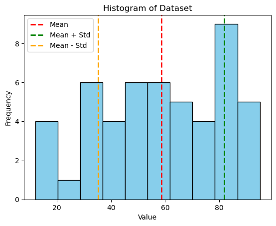

```python
import random
import matplotlib.pyplot as plt

# Step 1: Create dataset of 50 numbers
data = [random.randint(10, 100) for _ in range(50)]

# Step 2: Compute statistics
n = len(data)
mean = sum(data) / n
std = (sum((x - mean)**2 for x in data) / n) ** 0.5  # standard deviation

# Compute IQR (Interquartile Range)
sorted_data = sorted(data)
Q1 = sorted_data[n//4]
Q3 = sorted_data[3*n//4]
IQR = Q3 - Q1

print("Data:", data)
print("Mean:", mean)
print("Std Deviation:", std)
print("IQR:", IQR)

# Step 3: Plot histogram
plt.hist(data, bins=10, color='skyblue', edgecolor='black')

# Step 4: Draw lines for mean and mean ± std
plt.axvline(mean, color='red', linestyle='dashed', linewidth=2, label='Mean')         # draw a vertical line->axvline
plt.axvline(mean + std, color='green', linestyle='dashed', linewidth=2, label='Mean + Std')  #others line style are solid , dotted .........
plt.axvline(mean - std, color='orange', linestyle='dashed', linewidth=2, label='Mean - Std')

plt.title("Histogram of Dataset")
plt.xlabel("Value")
plt.ylabel("Frequency")
plt.legend()
plt.show()
```

## TASK 9

Generate two datasets (Dataset A with low spread and Dataset B with high spread). Plot both on the same figure using: boxplot scatter plot Explanation: First compute Q1, Q3, std deviation, and coefficient of variation. Then plot the boxplot to show IQR difference and scatter plot to show spread difference.

```
Dataset A: [51, 45, 47, 48, 50, 50, 53, 53, 55, 49, 53, 45, 54, 49, 55, 55, 49, 50, 47, 50]
Mean: 50.4 Std: 3.0886890422961004 IQR: 4 CV: 0.061283512743970245
Dataset B: [83, 76, 51, 50, 27, 78, 26, 48, 55, 98, 74, 33, 71, 79, 70, 24, 52, 23, 100, 45]
Mean: 58.15 Std: 23.6014300414191 IQR: 33 CV: 0.40587153983523816
```

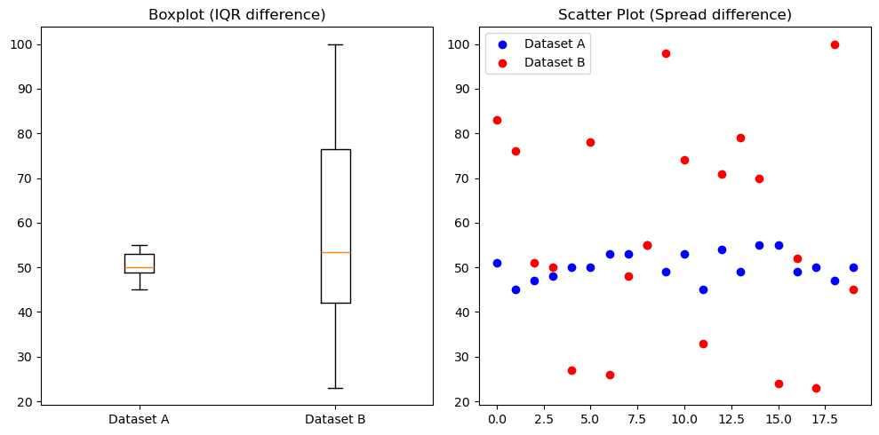

```python
import random
import matplotlib.pyplot as plt

# Step 1: Generate datasets
# Dataset A: low spread (values close together)
dataA = [random.randint(45, 55) for _ in range(20)]
# Dataset B: high spread (values spread out)
dataB = [random.randint(20, 100) for _ in range(20)]

# Step 2: Compute statistics
def compute_stats(data):
    n = len(data)
    mean = sum(data)/n
    std = (sum((x - mean)**2 for x in data)/n)**0.5
    sorted_data = sorted(data)
    Q1 = sorted_data[n//4]
    Q3 = sorted_data[3*n//4]
    IQR = Q3 - Q1
    CV = std / mean
    return mean, std, Q1, Q3, IQR, CV

meanA, stdA, Q1A, Q3A, IQR_A, CV_A = compute_stats(dataA)
meanB, stdB, Q1B, Q3B, IQR_B, CV_B = compute_stats(dataB)

print("Dataset A:", dataA)
print("Mean:", meanA, "Std:", stdA, "IQR:", IQR_A, "CV:", CV_A)
print("Dataset B:", dataB)
print("Mean:", meanB, "Std:", stdB, "IQR:", IQR_B, "CV:", CV_B)

# Step 3: Plot boxplot
plt.figure(figsize=(10,5))
plt.subplot(1,2,1)  # 1 row, 2 columns, first plot
plt.boxplot([dataA, dataB], labels=['Dataset A','Dataset B'])
plt.title("Boxplot (IQR difference)")

# Step 4: Plot scatter plot
plt.subplot(1,2,2)  # second plot
plt.scatter(range(len(dataA)), dataA, color='blue', label='Dataset A')
plt.scatter(range(len(dataB)), dataB, color='red', label='Dataset B')
plt.title("Scatter Plot (Spread difference)")
plt.legend()

plt.tight_layout()  # automatically adjusts the spacing between subplots and around labels so that everything fits nicely in the figure.
plt.show()
```

## TASK 10

Create a line plot of rolling standard deviation for a dataset of 40 values. Explanation: Use your rolling_std() function. Plot how the std deviation changes over time. This shows how dispersion varies across segments of data.

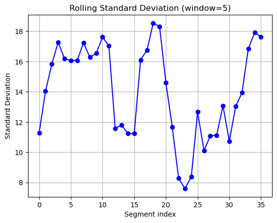

[output not shown]

```python
import random
import matplotlib.pyplot as plt

# Step 1: Define rolling_std function
def rolling_std(data, window):
    result = []
    for i in range(len(data) - window + 1):
        segment = data[i:i+window]
        mean = sum(segment)/window
        sd = (sum((x - mean)**2 for x in segment)/window)**0.5
        result.append(sd)
    return result

# Step 2: Create dataset of 40 numbers
data = [random.randint(50, 100) for _ in range(40)]

# Step 3: Set rolling window size and compute rolling std
window = 5
rolling_sd = rolling_std(data, window)

# Step 4: Plot rolling std
plt.plot(range(len(rolling_sd)), rolling_sd, marker='o', color='blue')
plt.title("Rolling Standard Deviation (window=5)")
plt.xlabel("Segment index")
plt.ylabel("Standard Deviation")
plt.grid(True)
plt.show()

# Optional: print dataset and rolling std
print("Data:", data)
print("Rolling Std Dev:",  rolling_sd)
```